```python
import sys
from collections import defaultdict
import time
import datetime
import pandas as pd
import sqlite3 as sql
import matplotlib.pyplot as plt
import seaborn as sns
```

```python
conn = sql.connect("yelp.sqlite")
```

# Task:

1) Inspect effiency of unclean dataset  
2) Clear out business which wasn't restaurant by using relation from previous cleaned  
3) Comparing effiency of both dataset  
3.1) Time spend on query  
3.2) Data Availability  
4) Export out as CSV

### 1) Inspect effiency of unclean dataset

```python
print(datetime.datetime.now().time())
b = datetime.datetime.now()

rangeA_df = pd.read_sql_query("SELECT * FROM review", conn)

print(datetime.datetime.now().time())
a = datetime.datetime.now()
print("-----")
delta2 = a-b
a-b
```

```
11:49:55.170048
12:06:15.673857
-----
```

```
datetime.timedelta(seconds=980, microseconds=591387)
```

```python
print(delta2)
delta2txt = ("0:16:20.591387")
```

```
0:16:20.591387
```

```python
#rangeAcount = len(rangeA_df.index)
rangeAcount = 6685900
print("Result of uncleaned data: "+ str(rangeAcount) +" Rows")
```

```
Result of uncleaned data: 6685900 Rows
```

### 2) Clear out business which wasn't restaurant by using relation from previous cleaned

```python
print(datetime.datetime.now().time())
b = datetime.datetime.now()

range_df = pd.read_sql_query("SELECT r.* FROM review r, restaurant b WHERE r.business_id = b.business_id", conn)

print(datetime.datetime.now().time())
a = datetime.datetime.now()
print("-----")
delta1 = a-b
a-b
```

```
13:03:16.064581
13:04:34.689089
-----
```

```
datetime.timedelta(seconds=78, microseconds=627506)
```

```python
print(delta1)
delta1txt = ("0:01:18.627506")
```

```
0:01:18.627506
```

```python
rangecount = len(range_df.index)
print("Result of uncleaned data: "+ str(rangecount) +" Rows")
```

```
Result of uncleaned data: 3893853 Rows
```

### 3) Comparing effiency of both dataset

#### 3.1) Time spend on query

```python
del1 = datetime.datetime.strptime(delta1txt, "%H:%M:%S.%f")
del2 = datetime.datetime.strptime(delta2txt, "%H:%M:%S.%f")
delta = abs(del1 - del2)
```

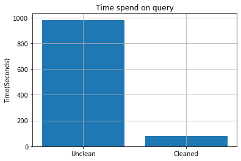

```python
names = ['Unclean', 'Cleaned']
values = [981, 79]
plt.figure()
plt.bar(names, values)
plt.title('Time spend on query')
plt.ylabel('Time(Seconds)')
plt.grid(True)
plt.show()
```

```python
delta
```

```
datetime.timedelta(seconds=901, microseconds=963881)
```

Time spend effiency of cleaned is faster by 902 seconds (about 15 mins)

#### 3.2) Data Availability

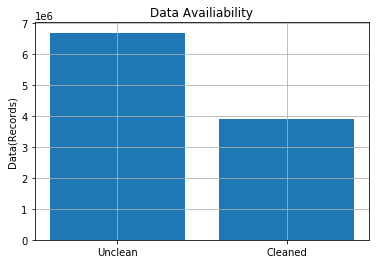

```python
names = ['Unclean', 'Cleaned']
values = [rangeAcount, rangecount]
plt.figure()
plt.bar(names, values)
plt.title('Data Availiability')
plt.ylabel('Data(Records)')
plt.ticklabel_format(axis="y", style="sci", scilimits=(0,0))
plt.grid(True)
plt.show()
```

```python
rangedelta = rangeAcount - rangecount
rangedelperc = ((rangedelta) * 100) / rangeAcount
```

```python
print(rangedelta)
print(rangedelperc)
```

```
2792047
41.76022674583826
```

Data availiability was reduced after cleaning by 2792047 records which reduce down the size by 41.76% from unclean version. The more reduce they are mean effiency they're boosted.

### 4) Export out as CSV

```python
range_df.to_csv('review.csv', index=False)
```

### Summary

This dataset was contain about 6,685,900 records of user review.

I test this two query effiency with computer with following specification:

- CPU: Intel Core i5-5200U CPU @ 2.20GHz
- Memory: DDR3 8 GBytes
- GPU: NVIDIA GeForce 940M with 4 GBytes VRAM DDR3
- OS: Windows 10 Pro

The large amount of data bring chaos experience to user and even scientist too, we decide to not normalize the dataset because its no need to be more normal, by the way it's need to be clean by remove records that weren't relate with *restaurant dataset* and we found the significant reduction by 41.76% but its loading speed is faster by 91.95% (about 15 minutes).  
*Scientist take about 3~4 times of attemption* to finish query of unclean version *due out of memory problem*.  
Which its data size still be our further question which need to be washed for query time effiency problem.

" As data scientist I give opinion for this as "Effiency Booster" because less data bring less time for process it.